# Reproducible Research_Peer assigment_1

Daniel Bekele

8/9/2021

# Load The Data

```r
setwd ("D:/my files/COURSERA/Reproducible Research/Project_1")
activity <- read_csv("activity.csv",show_col_types = FALSE)
activity
```

```
## # A tibble: 17,568 x 3
##    steps date       interval
##    <dbl> <date>        <dbl>
##  1    NA 2012-10-01        0
##  2    NA 2012-10-01        5
##  3    NA 2012-10-01       10
##  4    NA 2012-10-01       15
##  5    NA 2012-10-01       20
##  6    NA 2012-10-01       25
##  7    NA 2012-10-01       30
##  8    NA 2012-10-01       35
##  9    NA 2012-10-01       40
## 10    NA 2012-10-01       45
## # ... with 17,558 more rows
```

# Transform the data

```r
dates<-strptime(activity$date,"%Y-%m-%d")

activity$date<-dates

# Keep a list of all day
uniquedate<-unique(dates)

# Keep a list of all possible interval
uniqueinterval<-unique(activity$interval)
```

# Problem 1

What is mean total number of steps taken per day?

1.Calculate the total number of steps taken per day?

```r
# Divide the data frame for steps by day

dSteps<-split(activity$steps,dates$yday)

# Then,now calculate for total number of steps per day

totalStepsPD<-sapply(dSteps,sum,na.rm= TRUE)
totalStepsPD
```

```
##   274   275   276   277   278   279   280   281   282   283   284   285   286
##     0   126 11352 12116 13294 15420 11015     0 12811  9900 10304 17382 12426
##   287   288   289   290   291   292   293   294   295   296   297   298   299
## 15098 10139 15084 13452 10056 11829 10395  8821 13460  8918  8355  2492  6778
##   300   301   302   303   304   305   306   307   308   309   310   311   312
## 10119 11458  5018  9819 15414     0 10600 10571     0 10439  8334 12883  3219
##   313   314   315   316   317   318   319   320   321   322   323   324   325
##     0     0 12608 10765  7336     0    41  5441 14339 15110  8841  4472 12787
##   326   327   328   329   330   331   332   333   334
## 20427 21194 14478 11834 11162 13646 10183  7047     0
```

# Probelem 2

If you do not understand the difference between a histogram and a barplot, research the difference between them. Make a histogram of the total number of steps taken each day

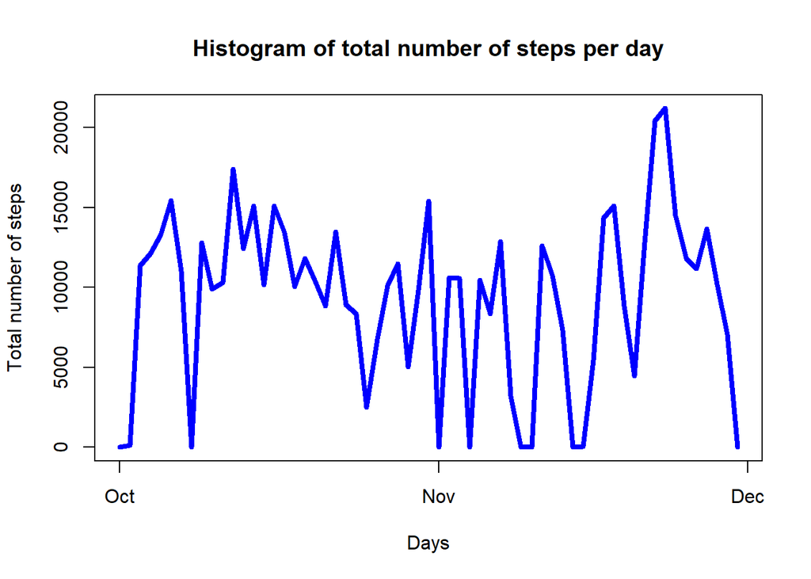

```r
# Let's plot histogram of total number of steps taken each day,on X-axis(number of day),and on y-axis(the total numbers of step)

plot(uniquedate,totalStepsPD,xlab = "Days",ylab = "Total number of steps",main = "Histogram of total number of steps per day",lwd=4,type = "l",col="blue")
```

# Problem 3

Calculate and report the mean and median of the total number of steps taken per day

```r
## Mean of total number of steps per day was calculated as below
meantstepsPD<-sapply(dSteps,mean,na.rm= TRUE)
meanDF<-data.frame(Date=uniquedate,MeanOfStepsPerDay=meantstepsPD, row.names = NULL)
meanDF
```

```
##          Date MeanOfStepsPerDay
## 1  2012-10-01               NaN
## 2  2012-10-02         0.4375000
## 3  2012-10-03        39.4166667
## 4  2012-10-04        42.0694444
## 5  2012-10-05        46.1597222
## 6  2012-10-06        53.5416667
## 7  2012-10-07        38.2465278
## 8  2012-10-08               NaN
## 9  2012-10-09        44.4826389
## 10 2012-10-10        34.3750000
## 11 2012-10-11        35.7777778
## 12 2012-10-12        60.3541667
## 13 2012-10-13        43.1458333
## 14 2012-10-14        52.4236111
```

[output cut: 47 more lines]

```r
## Median steps per day
MedianSPD <-sapply(dSteps, median,na.rm = TRUE)
medianDF<-data.frame(Date=uniquedate, MedianSPD=MedianSPD,row.names = NULL)
medianDF
```

```
##          Date MedianSPD
## 1  2012-10-01        NA
## 2  2012-10-02         0
## 3  2012-10-03         0
## 4  2012-10-04         0
## 5  2012-10-05         0
## 6  2012-10-06         0
## 7  2012-10-07         0
## 8  2012-10-08        NA
## 9  2012-10-09         0
## 10 2012-10-10         0
## 11 2012-10-11         0
## 12 2012-10-12         0
## 13 2012-10-13         0
## 14 2012-10-14         0
```

[output cut: 47 more lines]

# Problem 4

What is the average daily activity pattern?

```r
## 1.Make a time series plot(type="I")
## Use the 5-minute interval as (x-axis)
## Use the average number of steps taken as (y-axis)
## Divide the data frame for steps by 5 min interval

dInterv<-split(activity$steps,activity$interval)

# Find the average amount of steps per interval

avrgPerInterval<-sapply(dInterv,mean,na.rm= TRUE)

# Plot the time-series graph
plot(uniqueinterval,avrgPerInterval,type= "h", main= "Average number of steps per interval across all day",xlab= "5-minute Interval",ylab="Average number of steps across all day",lwd=4, col="red")

# 2.Which 5-minute interval, on average across all the days in the dataset, contains the maximum number of steps?

MaxIntrvlDay<-max(avrgPerInterval,na.rm = TRUE)
MaxLocate<-as.numeric(which(avrgPerInterval==MaxIntrvlDay))
MaxInterval<-uniqueinterval[MaxLocate]
MaxInterval
```

```
## [1] 835
```

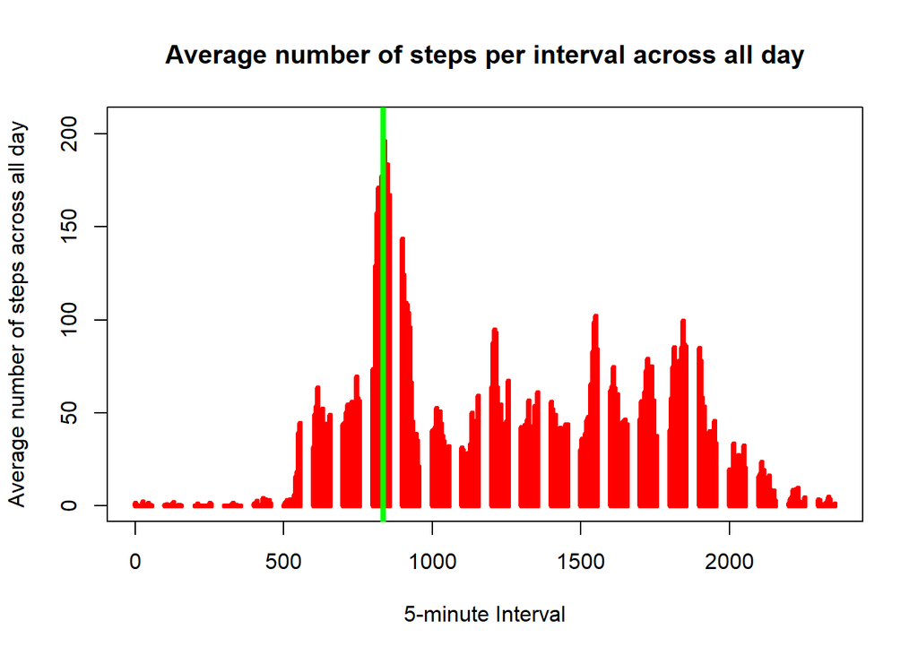

```r
## Displaying in the plot where max number is located
abline(v=MaxInterval,col= "green",lwd=4)
```

# Problem 5

# Imputing Missing Values

1.Calculate and report total number of missing value in the datasets

```r
miss<-is.na(activity)
sum(miss)
```

```
## [1] 2304
```

2.Devise a strategy for filling in all of the missing values in the dataset. The strategy does not need to be sophisticated. For example, you could use the mean/median for that day, or the mean for that 5-minute interval, etc.

```r
# First remove missing and replace with zero
meantstepsPD[is.na(meantstepsPD)]<-0

# Since, we have 288 interval we replicate our data 288 times

meanCol<-rep(meantstepsPD,288)
rawstep<-activity$steps
#Find any value missing in any raw steps data
stepmissi<-is.na(rawstep)
# Now replace missing value with mean

rawstep[stepmissi]<-meanCol[stepmissi]
```

3.Create a new dataset that is equal to the original dataset but with the missing data filled in.

```r
newdata<-activity
newdata$steps<-rawstep
newdata
```

```
## # A tibble: 17,568 x 3
##     steps date                interval
##     <dbl> <dttm>                 <dbl>
##  1  0     2012-10-01 00:00:00        0
##  2  0.438 2012-10-01 00:00:00        5
##  3 39.4   2012-10-01 00:00:00       10
##  4 42.1   2012-10-01 00:00:00       15
##  5 46.2   2012-10-01 00:00:00       20
##  6 53.5   2012-10-01 00:00:00       25
##  7 38.2   2012-10-01 00:00:00       30
##  8  0     2012-10-01 00:00:00       35
##  9 44.5   2012-10-01 00:00:00       40
## 10 34.4   2012-10-01 00:00:00       45
## # ... with 17,558 more rows
```

4.Make a histogram of the total number of steps taken each day and Calculate and report the mean and median total number of steps taken per day. Do these values differ from the estimates from the first part of the assignment? What is the impact of imputing missing data on the estimates of the total daily number of steps?

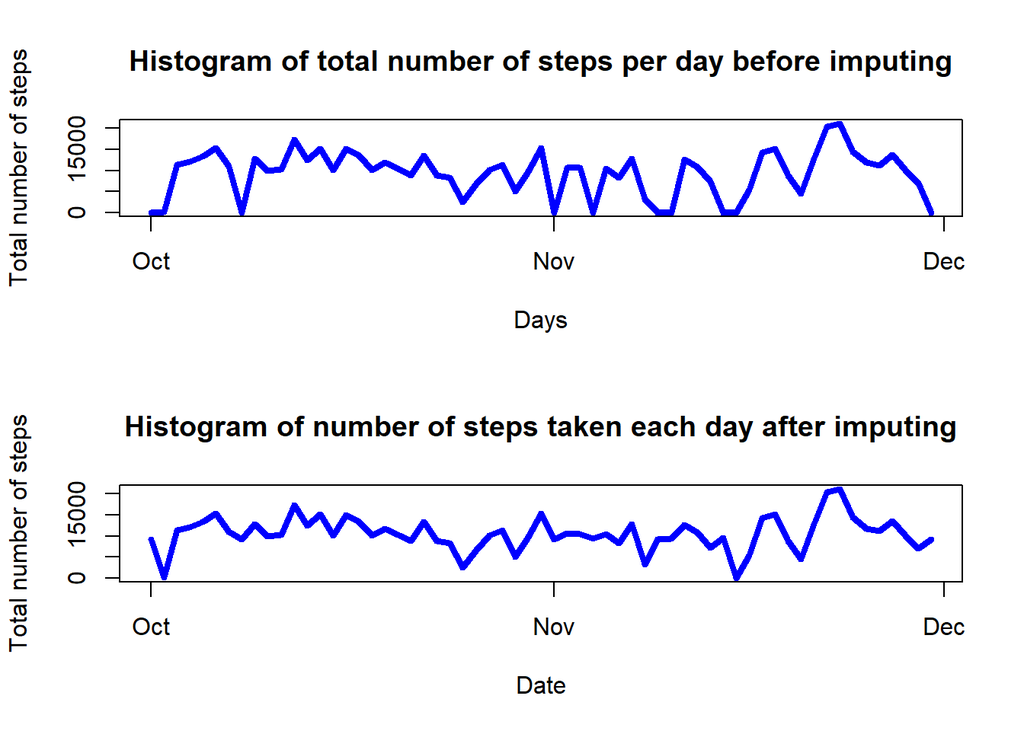

```r
# Split data frame of steps by day
newSteps<-split(newdata$steps,dates$yday)

# finding total number of steps over day

NtotalStepPD<-sapply(newSteps,sum)
par(mfcol=c(2,1))
#Original data

plot(uniquedate,totalStepsPD,xlab = "Days",ylab = "Total number of steps",main = "Histogram of total number of steps per day before imputing",lwd=4,type = "l",col="blue")

#Plot of histogram after imputing

plot(uniquedate,NtotalStepPD,xlab="Date",ylab="Total number of steps",main="Histogram of number of steps taken each day after imputing",lwd=4,type="l",col="blue")
```

Now Let’s calculate mean and median of the newly updated data like as we did before in the beginning side-by-side for comparison.Now we already imputed our missing values in the data,and we will have new mean and median calculated as below:

# Mean of original and new(imputed) data side-by-side.

```r
meanSPDnew<-sapply(newSteps,mean)
meanDFnew<-data.frame(date=uniquedate,meantstepsPD=meantstepsPD,meanSPDnew=meanSPDnew,row.names = NULL)
meanDFnew
```

```
##          date meantstepsPD meanSPDnew
## 1  2012-10-01    0.0000000 32.3355276
## 2  2012-10-02    0.4375000  0.4375000
## 3  2012-10-03   39.4166667 39.4166667
## 4  2012-10-04   42.0694444 42.0694444
## 5  2012-10-05   46.1597222 46.1597222
## 6  2012-10-06   53.5416667 53.5416667
## 7  2012-10-07   38.2465278 38.2465278
## 8  2012-10-08    0.0000000 32.2632378
## 9  2012-10-09   44.4826389 44.4826389
## 10 2012-10-10   34.3750000 34.3750000
## 11 2012-10-11   35.7777778 35.7777778
## 12 2012-10-12   60.3541667 60.3541667
## 13 2012-10-13   43.1458333 43.1458333
## 14 2012-10-14   52.4236111 52.4236111
```

[output cut: 47 more lines]

# Median of original and new(imputed) data side-by-side

## Notations:

1. MedianSPD represent median of orginal data
2. medianSPDnew represent median of imputed data(new)

```r
medianSPDnew<-sapply(newSteps, median)
medianDFnew<-data.frame(date=uniquedate,MedianSPD=MedianSPD,medianSPDnew=medianSPDnew,row.names = NULL)
medianDFnew
```

```
##          date MedianSPD medianSPDnew
## 1  2012-10-01        NA     36.09375
## 2  2012-10-02         0      0.00000
## 3  2012-10-03         0      0.00000
## 4  2012-10-04         0      0.00000
## 5  2012-10-05         0      0.00000
## 6  2012-10-06         0      0.00000
## 7  2012-10-07         0      0.00000
## 8  2012-10-08        NA     36.09375
## 9  2012-10-09         0      0.00000
## 10 2012-10-10         0      0.00000
## 11 2012-10-11         0      0.00000
## 12 2012-10-12         0      0.00000
## 13 2012-10-13         0      0.00000
## 14 2012-10-14         0      0.00000
```

[output cut: 47 more lines]

Do these values differ from the estimates from the first part of the assignment?

Answer: They only differed in where the observation has missing and the rest of estimates were stayed the same through out all observation in the datasets.

What is the impact of imputing missing data on the estimates of the total daily number of steps?

## Let’s calculate total daily number of steps-side by-side

```r
totalStepsPD<-sapply(dSteps,sum,na.rm= TRUE)
totalStepsPD
```

```
##   274   275   276   277   278   279   280   281   282   283   284   285   286
##     0   126 11352 12116 13294 15420 11015     0 12811  9900 10304 17382 12426
##   287   288   289   290   291   292   293   294   295   296   297   298   299
## 15098 10139 15084 13452 10056 11829 10395  8821 13460  8918  8355  2492  6778
##   300   301   302   303   304   305   306   307   308   309   310   311   312
## 10119 11458  5018  9819 15414     0 10600 10571     0 10439  8334 12883  3219
##   313   314   315   316   317   318   319   320   321   322   323   324   325
##     0     0 12608 10765  7336     0    41  5441 14339 15110  8841  4472 12787
##   326   327   328   329   330   331   332   333   334
## 20427 21194 14478 11834 11162 13646 10183  7047     0
```

```r
totalStepsPDnew<-sapply(newSteps,sum)
totalStepsPDnew
```

```
##       274       275       276       277       278       279       280       281
##  9312.632   126.000 11352.000 12116.000 13294.000 15420.000 11015.000  9291.812
##       282       283       284       285       286       287       288       289
## 12811.000  9900.000 10304.000 17382.000 12426.000 15098.000 10139.000 15084.000
##       290       291       292       293       294       295       296       297
## 13452.000 10056.000 11829.000 10395.000  8821.000 13460.000  8918.000  8355.000
##       298       299       300       301       302       303       304       305
##  2492.000  6778.000 10119.000 11458.000  5018.000  9819.000 15414.000  9220.306
##       306       307       308       309       310       311       312       313
## 10600.000 10571.000  9345.736 10439.000  8334.000 12883.000  3219.000  9304.674
##       314       315       316       317       318       319       320       321
##  9466.753 12608.000 10765.000  7336.000  9500.118    41.000  5441.000 14339.000
##       322       323       324       325       326       327       328       329
## 15110.000  8841.000  4472.000 12787.000 20427.000 21194.000 14478.000 11834.000
##       330       331       332       333       334
## 11162.000 13646.000 10183.000  7047.000  9281.670
```

# Problem 6

Are there differences in activity patterns between weekdays and weekends?

1.Create a new factor variable in the dataset with two levels “weekday” and “weekend” indicating whether a given date is a weekday or weekend day.

```r
# 0-6 represent week days,0-for Sunday and 1-for Monday

#Storing in weekdays

weekdays<-dates$wday

# Create new variable having two levels(1=weekday,0=weekend)

classifywday<-rep(0,length(weekdays)-1)

# Classify Monday to Friday as numeric value 1

classifywday[weekdays >=1 & weekdays <=5] <- 1

# Classify Saturday and Sunday as numeric value 0

classifywday[weekdays==6 & weekdays== 0] <- 0

# Create new factor variable that has labels (Weekends and weekdays)

FactorDay<-factor(classifywday,levels = c(1,0),labels = c("Weekdays","Weekends"))

# Create new column variable that contain this factors for all days throughout all observation

newdata$DayType<-FactorDay

# Divide into different data-frames

weeksdat<-newdata[newdata$DayType=="Weekdays",]
weekenddat<-newdata[newdata$DayType=="Weekends",]
```

2.Make a panel plot containing a time series plot (i.e. type = “l”) of the 5-minute interval (x-axis) and the average number of steps taken, averaged across all weekday days or weekend days (y-axis). See the README file in the GitHub repository to see an example of what this plot should look like using simulated data.

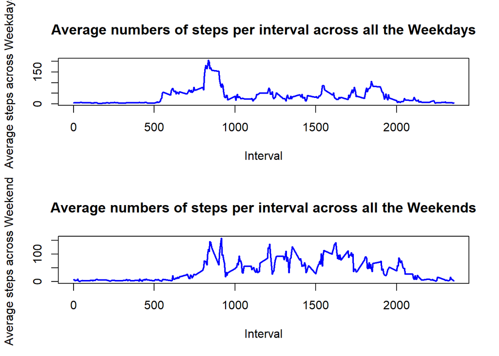

```r
# Split Weekdays and Weekends intro their interval and steps

weekdaysSplit<-split(weeksdat$steps,weeksdat$interval)
weekenddaysSplit<-split(weekenddat$steps,weekenddat$interval)

# Find mean for each interval

meanstepsPDweekdaysInterval<-sapply(weekdaysSplit,mean)
meanstepsPDweekendInterval<-sapply(weekenddaysSplit,mean)

par(mfcol=c(2,1))
plot(uniqueinterval,meanstepsPDweekdaysInterval,type="l",main="Average numbers of steps per interval across all the Weekdays",xlab="Interval",ylab="Average steps across Weekdays",lwd=2,col="blue")

plot(uniqueinterval,meanstepsPDweekendInterval,type="l",main="Average numbers of steps per interval across all the Weekends",xlab="Interval",ylab="Average steps across Weekend ",lwd=2,col="blue")
```